# Fakultät für Physik

## Physikalisches Praktikum P2 für Studierende der Physik

Versuch P2-11 (Stand: April 2024)

[Raum F1-14](https://labs.physik.kit.edu/img/Praktikum/Lageplan_P2.png)

# Polarisation und Doppelbrechung

Name: Alhelo Vorname: Fadi E-Mail: uylex@student.kit.edu

\begin{equation*} \begin{split} &\\ &\\ &\\ \end{split} \end{equation*}

Gruppennummer: Do-14

\begin{equation*} \begin{split} &\\ &\\ &\\ \end{split} \end{equation*}

Betreuer: __________________

\begin{equation*} \begin{split} &\\ &\\ &\\ \end{split} \end{equation*}

Versuch durchgeführt am: __________________

**Beanstandungen zu Protokoll Version _____:**

\begin{equation*} \begin{split} &\\ &\\ &\\ &\\ &\\ &\\ &\\ &\\ &\\ &\\ \end{split} %\text{\vspace{10cm}} \end{equation*}

Testiert am: __________________ Testat: __________________

# Durchführung

**Die Anleitung zu diesem Versuch finden Sie [hier](https://gitlab.kit.edu/kit/etp-lehre/p2-praktikum/students/-/blob/main/Polarisation/README.md).**

## Aufgabe 1: Polarisiertes Licht aus dem Wasserglas

**Hinweise zu Aufgabe 1 finden in der Datei Hinweise-Versuchsdurchfuehrung.md.**

- Strahlen Sie Licht durch ein mit Wasser gefülltes Glas und beobachten Sie das austretende Streulicht aus verschiedenen Richtungen durch einen Polarisationsfilter.
- Beschreiben und erklären Sie, was Sie beobachten.

**Lösung:**

#### Durchführung

Ein mit Wasser gefülltes Glas wird mit einem Licht von der seite beschient.  
Es wird dann das Wasser von oben und von der Seite Durch einen Polaristionsfilter beobachtet. Dabei wird der Winkel am Filter verändert.

[figure not shown]

**Abbildung 1:** Aufbau des Versuches

#### Auswertung

Es wird beobachtet, dass sich die Intensität der Reflexionen an den Rändern des Glases von dem eingestellten Winkel abhängt. Eine solche Beobachtung lässt sich von oben nicht sehen.

Es lässt sich Vermuten, dass diese Beobachtung durch eine Polarisation des Lichtes in der seitlichen Ebene ausgelösst wird.

Die Polarisation würde sich folgendermaßen erklären lassen:  
Licht breitet sich im Raum in Form einer EM-Welle fort, wobei die elektrischen Felder stehts senkrecht zur Ausbreitungsrichtung stehen.  
Tritt das Licht in das Wasser ein, so regt es die Wassermoleküle zu Dipolschwingungen an. Analog zu einer Antenne strahlen diese Dipole hauptsächlich senkrecht zur Schwingungsrichtung und kaum bis gar nicht in Schwingungsrichtung. Dies sorgt dafür, dass das zur Seite gebrochene Licht polarisiert sein kann.

## Aufgabe 2: Erzeugung und Untersuchung von Licht mit verschiedener Polarisation

**Hinweise zu Aufgabe 2 finden in der Datei Hinweise-Versuchsdurchfuehrung.md.**

- Erzeugen und untersuchen Sie die Intensitätsverteilungen von verschieden polarisiertem Licht.
- Bearbeiten Sie hierzu die folgenden Aufgaben.

### Aufgabe 2.1: Aufbau des Strahlengangs

- Bauen Sie geeignete Strahlengänge zur Erzeugung von **linear**, **elliptisch** und **zirkular** polarisiertem Licht auf.
- Bestimmen Sie die Intensitätsverteilungen des Lichts jeweils als Funktion des Winkels $\varphi$ eines zweiten linearen Polarisationsfilters.

**Lösung:**

#### Durchführung

Falls es zu Bereiche kommt, wo die Messwerte oberhalb der zulässigen $U_{max}$ des Messgeräts kommt, werden diese aus den Messreihen verworfen.

#### Auswertung

```python
#Imorting all needed libraries
import numpy as np
import matplotlib.pyplot as plt
import kafe2
import pandas as pd
from IPython.display import display, Math, Markdown

import warnings
warnings.filterwarnings('ignore')
```

```python
# Define model function for a sinus
def model_sin(rads, U_0,U_A,phi_0,omega):
    return U_0+U_A*np.sin(omega*rads+phi_0)
```

```python
# Making all Variables needed for the plots

# Errors that apply everywhere
degree_err = np.array([1])
rad_err = degree_err*(np.pi/180)
U_err = np.array([0.0015])

# Linear Polarized white light
degree_1 = np.linspace(0,180,37)
rad_1 = np.radians(degree_1)
U_1 = np.array([1992,1963,1910,1826,1715,1596,1462,1307,1147,990,838,697,562,444,340,265,205,169,157,169,209,266,350,464,591,724,883,1045,1202,1360,1510,1648,1759,1850,1917,1960,1980])/1000 # in mV

# Linear Polarized red light
degree_2 = np.linspace(0,180,37)
rad_2 = np.radians(degree_2)
U_2 = np.array([458,442,428,408,382,349,316,278,239,202,166,128,97,67,43,24,11,3,1,5,16,32,53,80,112,147,188,230,273,313,345,382,410,432,450,460,461])/1000 # in mV

# Zirkular Polarized light
degree_3 = np.linspace(0,180,37)
rad_3 = np.radians(degree_3)
U_3 = np.array([306,304,300,296,293,290,286,282,277,274,270,268,266,265,263,263,264,265,267,270,273,277,280,284,289,292,296,300,303,307,309,311,312,313,313,311,310])/1000 # in mV

# Eliptic Polarized light
d_1 = 60e-6 # in meters
degree_4 = np.linspace(0,180,37)
rad_4 = np.radians(degree_4)
U_4 = np.array([108,90,75,59,46,35,37,21,18,18,21,26,33,45,57,70,86,101,118,133,149,165,175,188,196,203,208,209,207,203,195,186,175,160,144,129,111])/1000 # in mV
# 1.3 ist nullwert

# Eliptic Polarized light
d_2 = 170e-6 # in meters
degree_5 = np.linspace(0,180,37)
rad_5 = np.radians(degree_5)
U_5 = np.array([147,149,151,153,155,156,156,156,154,153,152,150,148,145,143,140,138,136,133,131,129,127,126,126,125,126,126,127,128,130,132,134,137,140,143,146,148])/1000 # in mV
# 53.6 ist nullwert
```

blende wurde zugemacht damit dadurch die Maximale Spannung am Messgerät unter $4\mathrm V$ bleieben und somit gut aufgezeichnet werden.

##### Beide Lienear Polarisierte Lichter

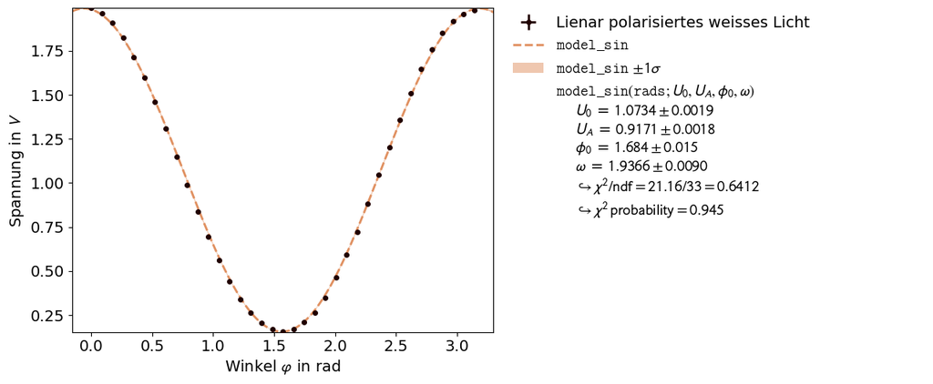

**Abbildung 2.1.1:** Fit der Messreihe für weisses Licht.

```python
# Fit for linear white light

# Make dataset
dataset = kafe2.XYContainer(x_data=rad_1,y_data=U_1)
dataset.axis_labels=[r'Winkel $\varphi$ in rad', 'Spannung in $V$']
dataset.label='Lienar polarisiertes weisses Licht'

dataset.add_error(axis='x',err_val=rad_err[0])
dataset.add_error(axis='y',err_val=U_err[0])



# Fit-Objekt erstellen
fit = kafe2.Fit(dataset,model_function=model_sin)

# make fit plot
fit.do_fit()
fit_result=kafe2.Plot([fit])

values_1 = fit.parameter_values


# show Fit results
fit_result.plot()
plt.show()
display(Markdown('**Abbildung 2.1.1:** Fit der Messreihe für weisses Licht.'))
```

Dieser Messung des weisen Lichtes muss noch angehängt werden, dass die Blende fast vollständig zu war und die Linse so verschoben, damit der maximale Wert bei eine $0\degree$ Versetzung nicht die $\mathrm {V_{max}}$ des Messgerätes überschreitet.

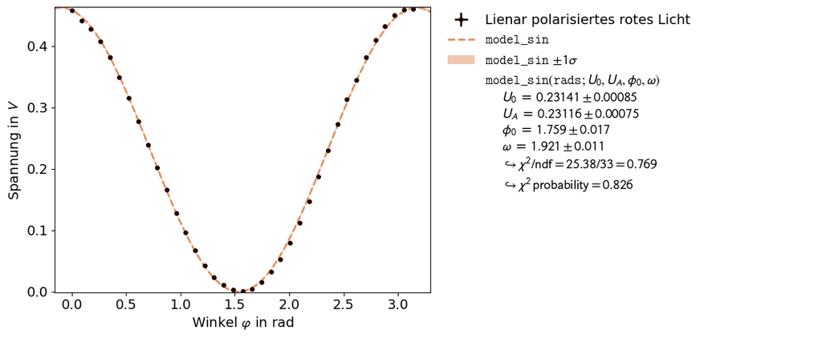

**Abbildung 2.1.2:** Darstellung der Messreihe für monochrom rotes Licht.

```python
# Fit for linear monochrome red light

# Make dataset
dataset = kafe2.XYContainer(x_data=rad_2,y_data=U_2)
dataset.axis_labels=[r'Winkel $\varphi$ in rad', 'Spannung in $V$']
dataset.label='Lienar polarisiertes rotes Licht'

dataset.add_error(axis='x',err_val=rad_err[0])
dataset.add_error(axis='y',err_val=U_err[0])



# Fit-Objekt erstellen
fit = kafe2.Fit(dataset,model_function=model_sin)

# make fit plot
fit.do_fit()
fit_result=kafe2.Plot([fit])


# show Fit results
fit_result.plot()
plt.show()
display(Markdown('**Abbildung 2.1.2:** Darstellung der Messreihe für monochrom rotes Licht.'))
```

Anhand der sehr guten $\chi^2$-probability der beiden Fits lässt sich aussagen, dass die Messungen sehr gut gelungen sind und dass die ermittelten Werte alle sehr gebräuchlich sinde.

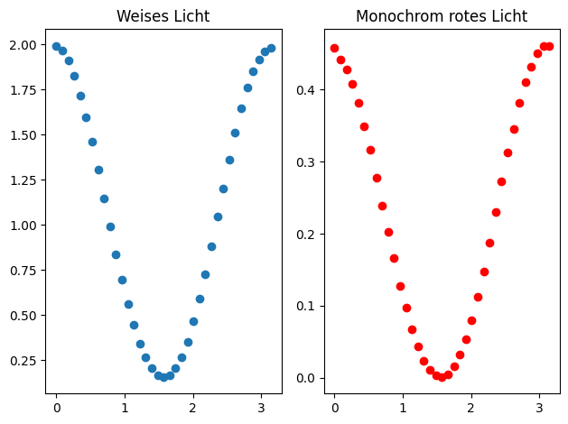

**Abbildung 2.1.3:** Darstellung der Messreihen neben einander.

```python
# Place both plots side by side
fig,axis = plt.subplots(1,2)

axis[0].scatter(x=rad_1,y=U_1)
axis[0].set_title('Weises Licht')

axis[1].scatter(x=rad_2,y=U_2,color='red')
axis[1].set_title('Monochrom rotes Licht')

fig.tight_layout()
plt.show()
display(Markdown('**Abbildung 2.1.3:** Darstellung der Messreihen neben einander.'))
```

Anhand der Abbildung ist gut zu erkennen, dass sich unsere Messwerte auf eine Sinuswelle liegen. Da die Messung am Maximum angefangen wurde, verschiebt sich die Welle um eine $\frac 14$-Periode wodurch ein Cosinus abgebildet wird.

#### Vergleich der zwei Eliptischen Polarisationen

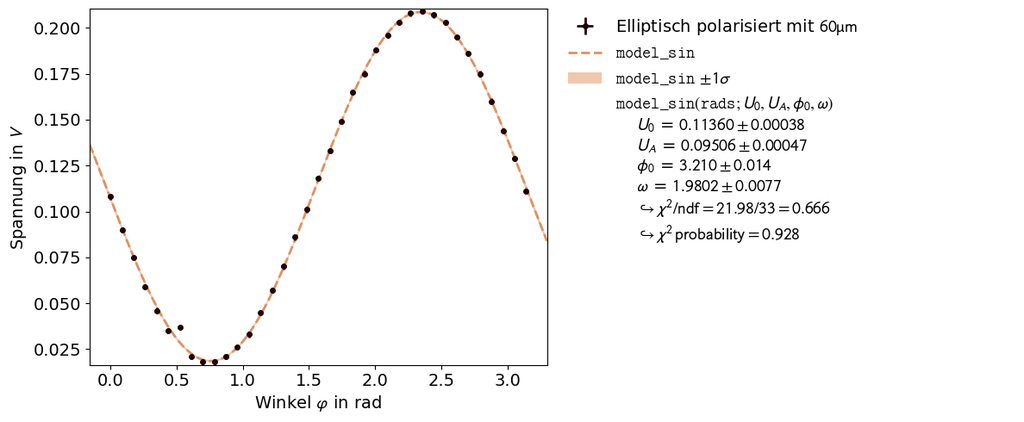

**Abbildung 2.1.4:** Darstellung der Messreihe für eliptisches Licht bei $60\mathrm{\mu m}$ dickem Glimmer.

```python
# Fit for eliptic red light

# Make dataset
dataset = kafe2.XYContainer(x_data=rad_4,y_data=U_4)
dataset.axis_labels=[r'Winkel $\varphi$ in rad', 'Spannung in $V$']
dataset.label=r'Elliptisch polarisiert mit $60\mathrm{\mu m}$'

dataset.add_error(axis='x',err_val=rad_err[0])
dataset.add_error(axis='y',err_val=U_err[0])



# Fit-Objekt erstellen
fit = kafe2.Fit(dataset,model_function=model_sin)

# make fit plot
fit.do_fit()
fit_result=kafe2.Plot([fit])


# show Fit results
fit_result.plot()
plt.show()
display(Markdown('**Abbildung 2.1.4:** Darstellung der Messreihe für eliptisches Licht bei $60\mathrm{\mu m}$ dickem Glimmer.'))
```

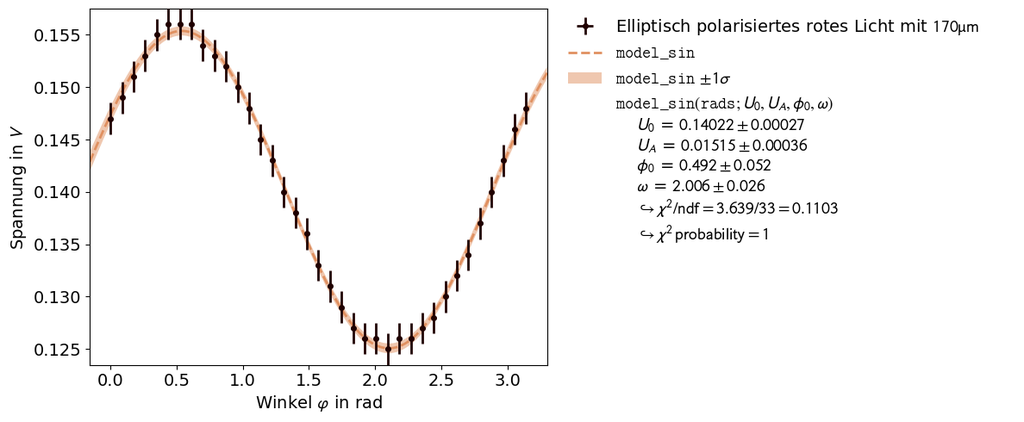

**Abbildung 2.1.5:** Darstellung der Messreihe für eliptisches Licht bei $170\mathrm{\mu m}$ dickem Glimmer.

```python
# Fit for eliptic red light

# Make dataset
dataset = kafe2.XYContainer(x_data=rad_5,y_data=U_5)
dataset.axis_labels=[r'Winkel $\varphi$ in rad', 'Spannung in $V$']
dataset.label=r'Elliptisch polarisiertes rotes Licht mit $170\mathrm{\mu m}$'
dataset.add_error(axis='x',err_val=rad_err[0])
dataset.add_error(axis='y',err_val=U_err[0])



# Fit-Objekt erstellen
fit = kafe2.Fit(dataset,model_function=model_sin)

# make fit plot
fit.do_fit()
fit_result=kafe2.Plot([fit])


# show Fit results
fit_result.plot()
plt.show()
display(Markdown('**Abbildung 2.1.5:** Darstellung der Messreihe für eliptisches Licht bei $170\mathrm{\mu m}$ dickem Glimmer.'))
```

Die statisch gewählte Ungenauigkeit der Spannung welche angenommen wurde zeigt hier aber ihre Probleme. Es wird erkennlich, dass je näher die Messungen aneinander liegen, desto sichtbarer wird der Fehler.

##### Zirkulares Licht

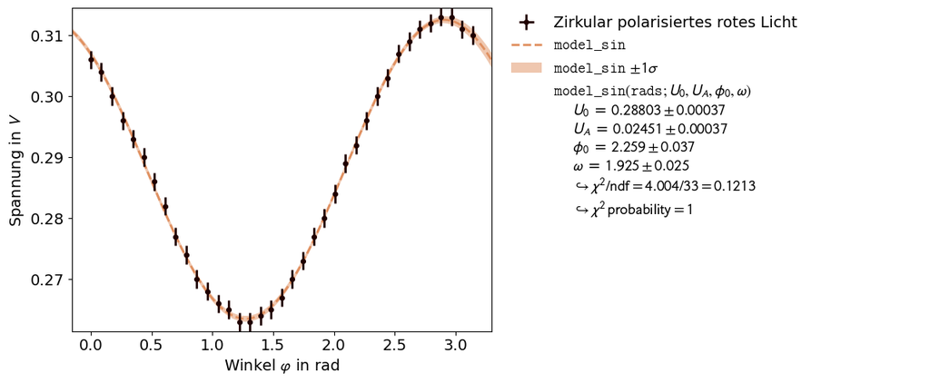

**Abbildung 2.1.6:** Darstellung der Messreihe für zirkulares Licht.

```python
# Fit for circular red light

# Make dataset
dataset = kafe2.XYContainer(x_data=rad_3,y_data=U_3)
dataset.axis_labels=[r'Winkel $\varphi$ in rad', 'Spannung in $V$']
dataset.label='Zirkular polarisiertes rotes Licht'

dataset.add_error(axis='x',err_val=rad_err[0])
dataset.add_error(axis='y',err_val=U_err[0])



# Fit-Objekt erstellen
fit = kafe2.Fit(dataset,model_function=model_sin)

# make fit plot
fit.do_fit()
fit_result=kafe2.Plot([fit])


# show Fit results
fit_result.plot()
plt.show()
display(Markdown('**Abbildung 2.1.6:** Darstellung der Messreihe für zirkulares Licht.'))
```

Es ergibt sich aus dem Fit, dass eine Spannungsamplitude von $U_A \approx 0.0245\mathrm V$ vorliegt.

Aus der Theorie wird aber bei zirkularem Licht erwatrtet, dass es keine Schwingung geben soll, sondern eine konstante Intensität in jede Richtung.  
Bei viel präzisere Messungen dieses Versuches, welche nicht wie hier im Praktikum per Hand justiert wurden, bestätigt sich auch dies.  
Daher liegt es nahe, dass der Grund für diese Schwingung menschliche Ungenauigkeit bei dem Ausrichten der einzelnen Bauelemente im Lichtgang. Somit konnte auch keine genaue zirkulare Welle entstehen.

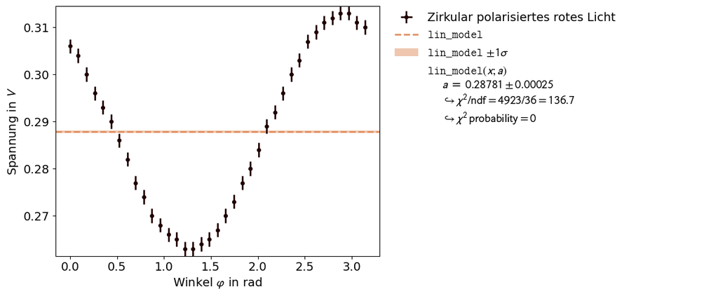

**Abbildung 2.1.7:** Darstellung der Messreihe gegen die erwartete gerade bei zirkulares Licht.

```python
def lin_model (x,a):
    return a

# Linear fit for circular red light

# Make dataset
dataset = kafe2.XYContainer(x_data=rad_3,y_data=U_3)
dataset.axis_labels=[r'Winkel $\varphi$ in rad', 'Spannung in $V$']
dataset.label='Zirkular polarisiertes rotes Licht'

dataset.add_error(axis='x',err_val=rad_err[0])
dataset.add_error(axis='y',err_val=U_err[0])



# Fit-Objekt erstellen
fit = kafe2.Fit(dataset,model_function=lin_model)

# make fit plot
fit.do_fit()
fit_result=kafe2.Plot([fit])


# show Fit results
fit_result.plot()
plt.show()
display(Markdown('**Abbildung 2.1.7:** Darstellung der Messreihe gegen die erwartete gerade bei zirkulares Licht.'))
```

Anbei wurden die Werte noch mit der erwarteten Gerade für die Messung verglichen.  
Es wird sehr schnell deutlich, dass die Werte vollkommen unpassend sind.

### Aufgabe 2.2: Differenz der Brechungsindizes der beobachteten Strahlen

Bestimmen Sie die Differenz $\Delta n=\left(n_{\beta} - n_{\gamma}\right)$ der beobachteten Strahlen. Verwenden Sie hierzu die gemessenen Intensitätsverteilungen für den Fall elliptisch polarisierten Lichts.

**Lösung:**

#### Vorbereitung

Um die Differenz der Brechungsindizes zu berechnen, wird die in der [Vorbereitungshilfe](https://gitlab.kit.edu/kit/etp-lehre/p2-praktikum/students/-/blob/main/Polarisation/doc/Hinweise-Versuchsdurchfuehrung.md?ref_type=heads) angegebene Formel $$ \Delta n = \frac{\lambda_0}{2\pi d} \, \arctan\left( \sqrt{\frac{U_{min}}{U_{max}}} \right) $$ verwendet.
Dabei ist $d$ die Dicke des Verzögerungsplättchens und $\lambda_0$ die Wellenlänge des Lichtes im Vakuum.

#### Bearbeitung

```python
def del_n(wave, d, min,max):
        return wave*np.arctan(np.sqrt(min/max))/(2*np.pi*d)
```

```python
# Define variables
lambda_0 = 630e-9


# Minima and Maxima of the potential
U_4_min = np.min(U_4)
U_4_max = np.max(U_4)

U_5_min = np.min(U_5)
U_5_max = np.max(U_5)

del_60 = del_n(wave=lambda_0,d=d_1 ,min=U_4_min,max=U_4_max)
del_170 = del_n(wave=lambda_0,d=d_2 ,min=U_5_min,max=U_5_max)

uncertianty = 8.44E-5

display(Math(rf'\text{{Durch die Messung erschließt sich:}}\, \Delta n_1=({del_60:.4E}\pm{uncertianty:.02E}) \; \text{{und}}\, \Delta n_2=({del_170:.4E}\pm{uncertianty:.02E})'))
```

$\displaystyle \text{Durch die Messung erschließt sich:}\, \Delta n_1=(4.7703E-04\pm8.44E-05) \; \text{und}\, \Delta n_2=(4.3063E-04\pm8.44E-05)$

Es ist zu sehen, dass die beiden errechneten Untershiede innerhalb der gegenseiten Unsicherheit liegen. Dies ist auch zu erwarten, da es sich bei beiden Plättschen um das selbe Material handelte.

## Aufgabe 3: Beobachtungen mit polarisiertem Licht

**Hinweise zu Aufgabe 3 finden in der Datei Hinweise-Versuchsdurchfuehrung.md.**

- Beobachten Sie einige Beispiele, wo Doppelbrechung im Alltag auftaucht und z.T. auch technisch angewandt wird.
- Bearbeiten Sie hierzu die folgenden Aufgaben.

### Aufgabe 3.1: Doppelbrechung am Klebefilm

- An handelsüblichen Klebefilmen tritt Doppelbrechung auf, die Sie mit linear polarisiertem Licht sichtbar machen können.
- Untersuchen Sie die am Versuch ausliegenden Klebefilme und beschreiben Sie, was Sie beobachten.
- Stellen Sie eigene Klebefilmkonstruktionen her, um sich mit dem beobachteten Phänomen vertraut zu machen.
- Fügen Sie Ihrem Protokoll entsprechende Aufnahmen zu.

**Lösung:**

#### Durchführung

Für Aufgabe 3.1 wird nun ein zu untersuchendes Objekt zwischen Analysefilter und Polarisationsfilter geschalten und das durscheinende Licht auf eine Leinwand projiziert. Zuvor werden die beiden Filter so ausgerichtet, dass nach dem Analysefitler kein Licht hindurch kommt. So wird die Stellung gefunden, bei der der Winkelunterschied zwischen beiden Filtern $90°$ beträgt. Damit können nachfolgenden Bilder in Abhängigkeit dieses Winkelunterschieds aufgezeichnet werden.

| 0° | 30° | 60° | 90° |
| --- | --- | --- | --- |

#### Auswertung

Man erwartet, dass das Licht nicht durch den zweiten Filter bei einer $90°$ Verdrehung durchkommt und genau dies ist im Versuch zu sehen. Allerdings nur wenn das Licht durch das Glas geht.

### Aufgabe 3.2: Doppelbrechung unter mechanischer Spannung

- Eine technische Anwendung der Doppelbrechung besteht in der Sichtbarmachung von Stellen an Materialien, die besonderer mechanischer Spannung unterliegen.
- Am Versuch liegen einige Modelle aus. Versetzen Sie diese mechanischer Spannung und beobachten Sie die Transmission linear polarisierten Lichts.
- Beschreiben Sie, was Sie beobachten.
- Fügen Sie Ihrem Protokoll entsprechende Aufnahmen zu.

**Lösung:**

#### Durchführung

Auch bei dieser Aufgabe wird der Analysefilter wie in 3.1 auf 90° kalibriert, um anschließend Plastikfiguren unter mechanischem Druck zu untersuchen.

| Keine Belastung | Geringe Belastung | Hohe Belastung |
| --- | --- | --- |

#### Auswertung

Es wurden für die Aufnahmen eienen Winkel von etwa $70°$ eingestellt. Somit wurden die untershiede der Polarisation unter Druck gut sichtbar als auch die Form des Bauteils.

Es wird erkannt, dass bei zunehmender Kraft die Ränder und Kanten des Bauteils den meisten Druck erfahren. Somit kommt es genau dort zu leichte Verformungen des Bauteils. Diese Verformung sorgt dann dafür, dass das Licht an diesen stellen eine Doppelbrechung erfährt.

Dabei wird auffällig, dass die Menge an Licht, welches diese Doppelbrechung erfährt, proportional zur mechanischen Kraft ist.